```python
import numpy as np
import matplotlib.pyplot as plt
from sklearn.tree import DecisionTreeClassifier, plot_tree
from sklearn.ensemble import RandomForestClassifier
from sklearn.metrics import roc_curve
from sklearn import metrics


horseshoes = np.genfromtxt('dataSetHorseshoes.csv',delimiter=',')
X = horseshoes[:,1:3]
Y = horseshoes[:,0]
```

# Decision trees and random forests

```python
def makeDecisionTree(depth=None):
    decisionTree = DecisionTreeClassifier(random_state=0, max_depth=depth)
    decisionTree.fit(X,Y)
    plt.figure(figsize=(15,15))
    plot_tree(decisionTree)
    return decisionTree

def visualizeDecisionSurface(tree, title):
    xx,yy = np.meshgrid(np.arange(np.min(X[:,0])-1, np.max(X[:,0])+1, 0.1),np.arange(np.min(X[:,1])-1, np.max(X[:,1])+1, 0.1))
    xygrid = np.c_[xx.ravel(), yy.ravel()]
    preds = tree.predict(xygrid)
    decisionstats = tree.predict_proba(xygrid)[:,1]

    fig, ax = plt.subplots()
    im = ax.pcolormesh(xx, yy, decisionstats.reshape(xx.shape), cmap="turbo")
    fig.colorbar(im)
    class0 = horseshoes[horseshoes[:,0]==0, :]
    class1 = horseshoes[horseshoes[:,0]==1, :]
    ax.scatter(class0[:,1],class0[:,2], label="class0", alpha=0.7)
    ax.scatter(class1[:,1],class1[:,2], label="class1", alpha=0.7)
    ax.contour(xx, yy, preds.reshape(xx.shape), levels=[0.5], colors="white", linewidths=[2])

    ax.legend()
    ax.set_title(title)
    plt.show()
```

## 1)

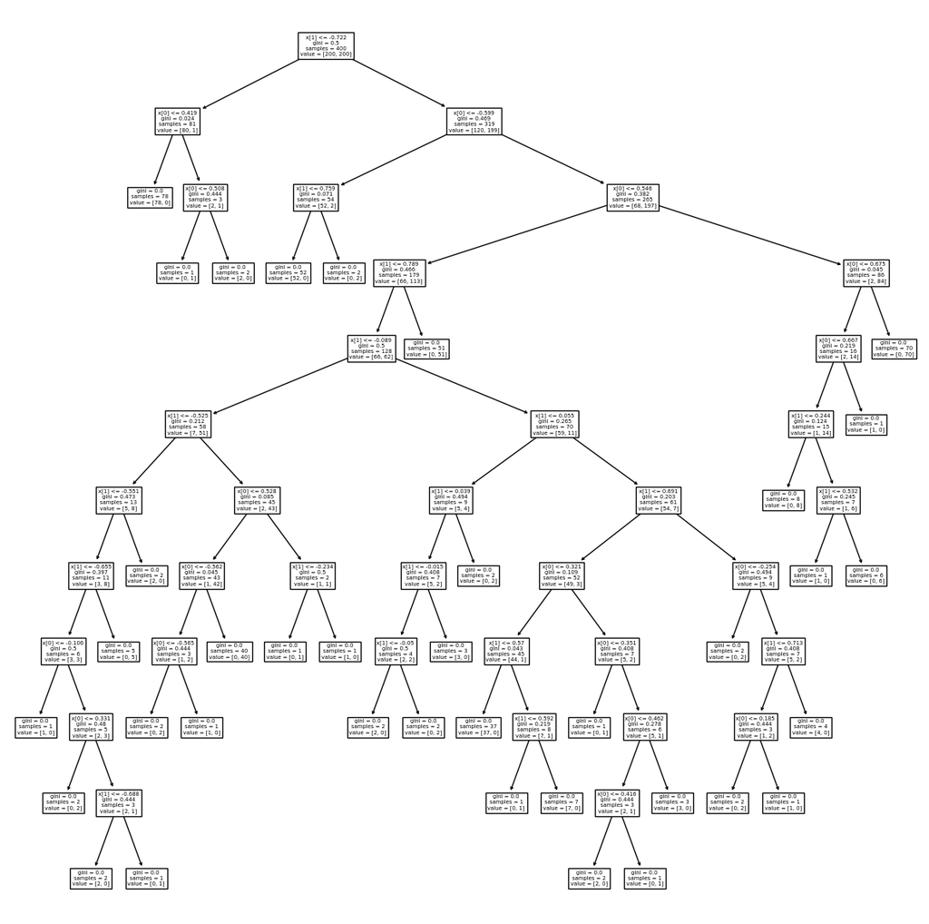

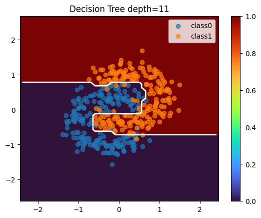

```python
maxTree = makeDecisionTree()
visualizeDecisionSurface(maxTree, f"Decision Tree depth={maxTree.get_depth()}")
```

## 2)

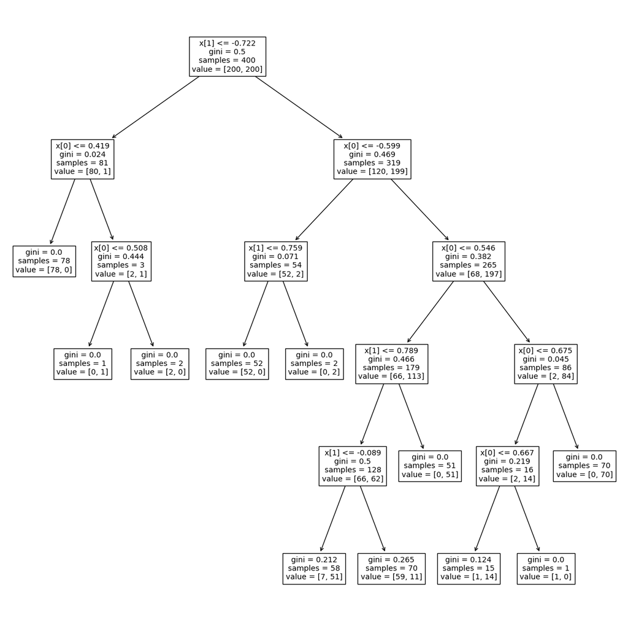

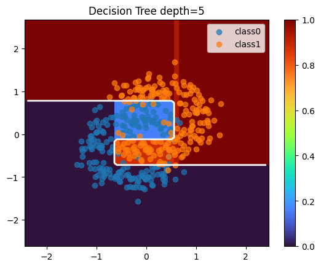

```python
reasonableTree = makeDecisionTree(5)
visualizeDecisionSurface(reasonableTree, f"Decision Tree depth={reasonableTree.get_depth()}")
```

## 3)

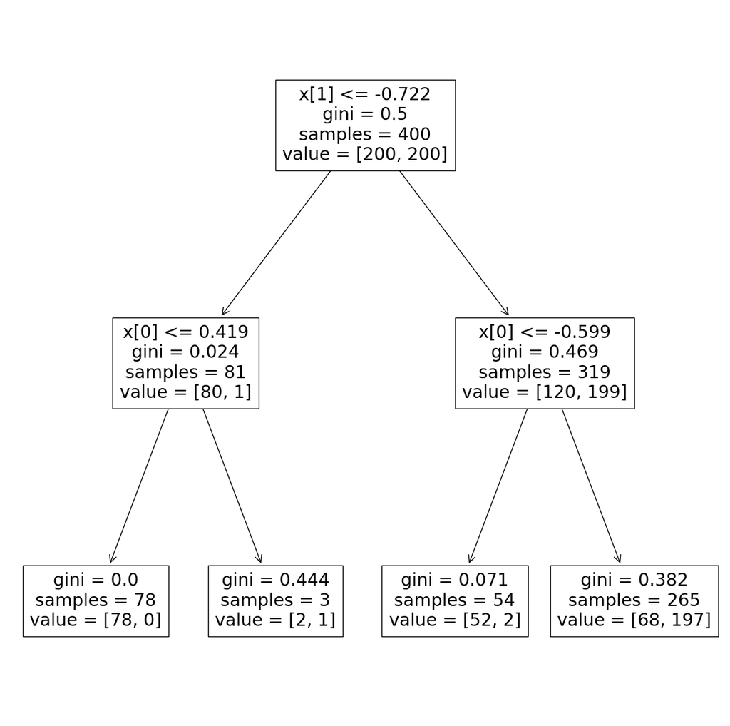

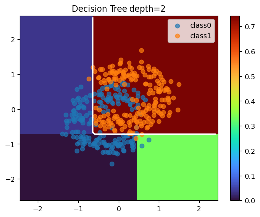

```python
shortTree = makeDecisionTree(2)
visualizeDecisionSurface(shortTree, f"Decision Tree depth={shortTree.get_depth()}")
```

## 4)

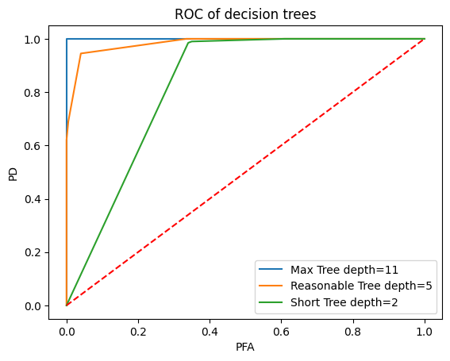

```python
maxTreeDecisionStats = maxTree.predict_proba(X)[:,1]
reasonableTreeDecisionStats = reasonableTree.predict_proba(X)[:,1]
shortTreeDecisionStats = shortTree.predict_proba(X)[:,1]

d = {"Max Tree depth=11":maxTreeDecisionStats, "Reasonable Tree depth=5":reasonableTreeDecisionStats, "Short Tree depth=2":shortTreeDecisionStats}

fig, ax = plt.subplots()
for label, decision_stats in d.items():
    pFA, pD, _ = roc_curve(Y, decision_stats)
    ax.plot(pFA, pD, label=label)

ax.plot([0, 1], [0, 1],'r--')
ax.set_ylabel('PD')
ax.set_xlabel('PFA')
ax.set_title('ROC of decision trees')
ax.legend()
plt.show()
```

## 5)

As depth increases, the variance of the model increases and bias decreases. There is more variance because the model is more overfitted to the data and thus will likely perform significantly different when new data is introduced. We can see the effect of increased depth on decreasing bias in the ROC. Since the ROC was generated from testing using the training data, the performance of high depth trees is very good as seen by a perfect ROC for the max tree.

As depth decreases, the bias of the model increases and variance decreases. With lower variance, it's likely that the decision statistic generated by new data will be similar to the decision statistics generated by the training data. With higher bias, there is more systematic errors in the predictions. This is evident in the decision statistic surfaces plots since we can see more blue (class 0) data points in areas that are in the more orange (class 1) decision regions as depth decreases. This signifies more incorrect predictions.

## 6)

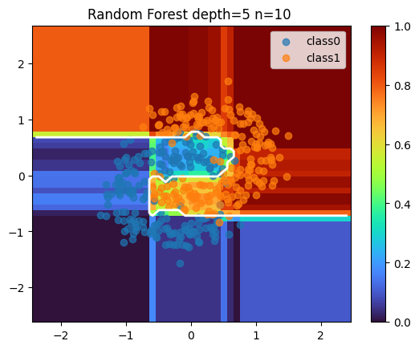

```python
randomForest = RandomForestClassifier(max_depth=5, n_estimators=10, random_state=0)
randomForest.fit(X,Y)
visualizeDecisionSurface(randomForest, f"Random Forest depth=5 n=10 ")
```

## 7)

# Ensemble methods

## 9)

### 9a)

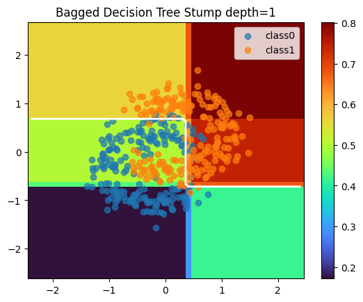

```python
from sklearn.ensemble import BaggingClassifier
bagged_stump = BaggingClassifier(DecisionTreeClassifier(max_depth=1, random_state=0))
bagged_stump.fit(X,Y)
visualizeDecisionSurface(bagged_stump, f"Bagged Decision Tree Stump depth=1")
```

### 9b)

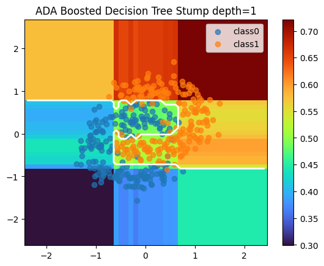

```python
from sklearn.ensemble import AdaBoostClassifier
boosted_stump = AdaBoostClassifier(DecisionTreeClassifier(max_depth=1, random_state=0))
boosted_stump.fit(X,Y)
visualizeDecisionSurface(boosted_stump, f"ADA Boosted Decision Tree Stump depth=1")
```

## 10)

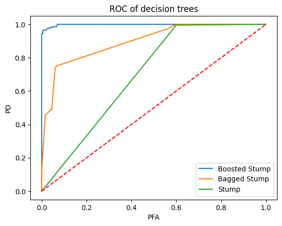

```python
stump = DecisionTreeClassifier(max_depth=1, random_state=0)
stump.fit(X,Y)
stump_decisionStats = stump.predict_proba(X)[:,1]
boosted_stump_decisionStats = boosted_stump.predict_proba(X)[:,1]
bagged_stump_decisionStats = bagged_stump.predict_proba(X)[:,1]

d = {"Boosted Stump":boosted_stump_decisionStats, "Bagged Stump":bagged_stump_decisionStats, "Stump":stump_decisionStats}

fig, ax = plt.subplots()
for label, decision_stats in d.items():
    pFA, pD, _ = roc_curve(Y, decision_stats)
    ax.plot(pFA, pD, label=label)

ax.plot([0, 1], [0, 1],'r--')
ax.set_ylabel('PD')
ax.set_xlabel('PFA')
ax.set_title('ROC of decision trees')
ax.legend()
plt.show()
```

## 11)

Bagging works by creating many variations of the decision tree stump by sampling the data with replacement, and then averaging the decision statistics. This effectively decreases variance as the model is created to fit many different data sets. However, since the different datasets are all sampled from the same training dataset, there is no guarantee that the model will predict brand new data not sampled from the training set well.

Boosting works by iteratively weighting incorrect classifications higher and correct classifications lower. This reduces bias because after each iteration, a new decision region is made based on the newly weighted data points. This results in the model fitting the training data very well as with more and more iterations, more decision regions will be made to classify the training data well.